# Evolución del rendimiento competitivo en selecciones nacionales: Patrones de goles, ventaja local y cambios temporales (2000-2026)

# 1 Introducción

## 1.1 Descripción del dataset

El dataset seleccionado contiene información sobre **partidos internacionales de fútbol** disputados desde 1872 hasta la actualidad, con énfasis en el período 2000–2026. Comprende más de 25 000 registros de encuentros entre selecciones nacionales en distintas competiciones.

Las variables disponibles son:

| Variable | Descripción |
| --- | --- |
| `date` | Fecha del partido |
| `home_team` | Selección local |
| `away_team` | Selección visitante |
| `home_score` | Goles del equipo local |
| `away_score` | Goles del equipo visitante |
| `tournament` | Tipo de competición |
| `country` | País anfitrión |
| `neutral` | Cancha neutral (TRUE / FALSE) |

**Fuente:** [All International Football Results — Kaggle](https://www.kaggle.com/datasets/patateriedata/all-international-football-results)

## 1.2 Justificación del dataset

El dataset fue elegido por su **volumen** (> 25 000 registros desde 2000, 8 variables), su **acceso público** desde Kaggle y su **relevancia histórica**: permite observar la profesionalización, la expansión global y los cambios competitivos del fútbol a lo largo de más de 150 años. Su magnitud posibilita un análisis robusto con estadísticas confiables y aplica un amplio rango de técnicas — análisis temporal, estadística descriptiva, correlaciones y agrupamiento de datos.

## 1.3 Objetivos del análisis

Se busca responder las siguientes preguntas:

1. ¿Cómo fue el promedio de goles en cada Mundial?
2. ¿El rendimiento ofensivo de las selecciones históricamente dominantes cambió entre la primera (2002–2010) y la segunda década (2014–2022)?
3. ¿Cuánto influye jugar de local según el tipo de torneo?
4. ¿Ha cambiado el promedio de goles a lo largo de los años?
5. ¿Cómo se distribuyen los resultados? ¿Predominan los partidos cerrados o las goleadas?
6. ¿Cómo evolucionó Argentina ofensiva y defensivamente entre 2000 y 2026?
7. ¿Qué patrones permiten anticipar el Mundial 2026?

# 2 Limpieza y preparación de datos

Las transformaciones realizadas fueron:

- Conversión de la columna `date` a formato `Date` con `as.Date()`.
- Extracción del **año** como nueva variable `year`.
- Filtrado de registros desde el año **2000** en adelante (25336 partidos).
- Conversión de `neutral` de texto a booleano.
- Creación de **variables derivadas**: `total_goles`, `resultado`, `diferencia`, `tipo_torneo`, `gano_local` y `tipo_resultado`.

Luego de la limpieza quedaron **25.336 partidos** con **15 variables** (8 originales + columnas derivadas).

# 3 Análisis exploratorio

## 3.1 Pregunta 1: ¿Cómo fue el promedio de goles en cada Mundial?

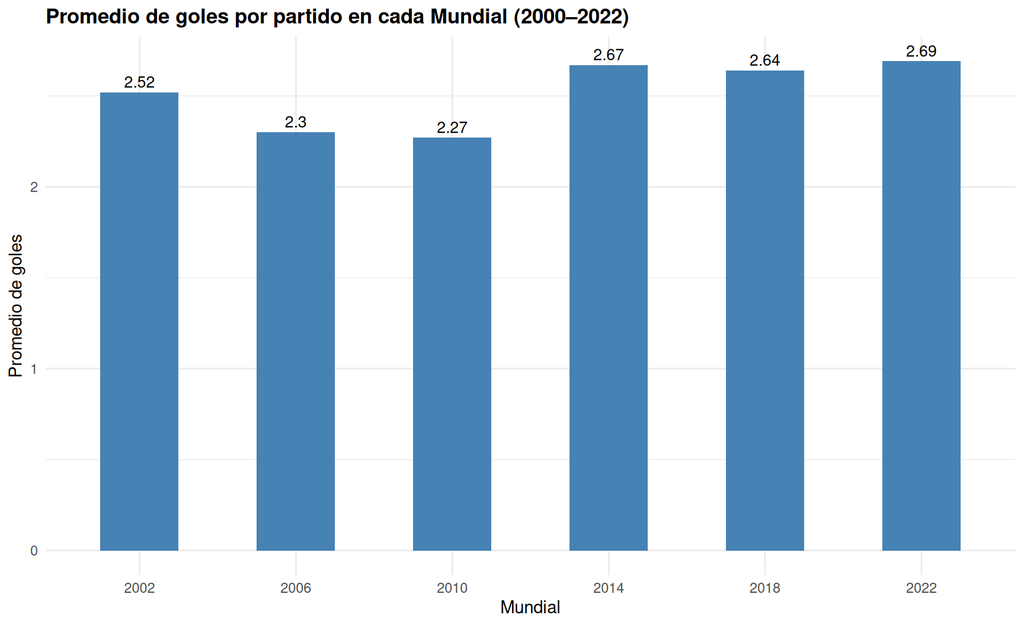

El promedio de goles oscila entre **2.27** y **2.69** goles por partido. A partir de 2010, los Mundiales muestran una tendencia alcista, llegando a **2.69** en 2022. —